# [WhatWouldAiThink.com](https://www.whatwouldaithink.com)

### Regression - Classification - Clustering

### December 2022

### This notebook is made for the analysis of craft beer published on: whatwouldaithink.com

#### Copyright © 2022-Present whatwouldaithink.com - All Rights Reserved

```python
import os
import math

# handling data
import pandas as pd
import numpy as np

# for plotting and colormaps
import matplotlib as mpl
from matplotlib.lines import Line2D
import matplotlib.pyplot as plt
from matplotlib.colors import ListedColormap

# load and save models
from joblib import load
from joblib import dump
from pathlib import Path

import warnings

warnings.filterwarnings("ignore")

# custom plotting class
from plotting.customPlotting import Plot2D as cPlot2D

showSubPlotsSeparately = True

pd.set_option("display.max_colwidth", 200)
pd.set_option("display.max_columns", 10)

# equal size, and axis for all figures
figSize = 5
x_min = 0.02
x_max = 0.11
y_min = 0
y_max = 160


def pseudorandom():
    np.random.seed(42)
```

**Read the csv file into a panda data frame.**

```python
# The data are from https://www.kaggle.com/nickhould/craft-cans?select=beers.csv
path = Path("beers.csv")
df_raw = pd.read_csv(os.path.join(path.parent.absolute(), "Data_Beers", "beers.csv"))
```

# 1. Preprocess the data

**First check the data.**

```python
display(df_raw.info())
```

```
<class 'pandas.core.frame.DataFrame'>
RangeIndex: 2410 entries, 0 to 2409
Data columns (total 8 columns):
 #   Column      Non-Null Count  Dtype
---  ------      --------------  -----
 0   Unnamed: 0  2410 non-null   int64
 1   abv         2348 non-null   float64
 2   ibu         1405 non-null   float64
 3   id          2410 non-null   int64
 4   name        2410 non-null   object
 5   style       2405 non-null   object
 6   brewery_id  2410 non-null   int64
 7   ounces      2410 non-null   float64
dtypes: float64(3), int64(3), object(2)
memory usage: 150.8+ KB
```

```
None
```

**Check the first 5 samples.**

```python
display(df_raw.head())
```

|  | Unnamed: 0 | abv | ibu | id | name | style | brewery_id | ounces |
| --- | --- | --- | --- | --- | --- | --- | --- | --- |
| 0 | 0 | 0.050 | NaN | 1436 | Pub Beer | American Pale Lager | 408 | 12.0 |
| 1 | 1 | 0.066 | NaN | 2265 | Devil's Cup | American Pale Ale (APA) | 177 | 12.0 |
| 2 | 2 | 0.071 | NaN | 2264 | Rise of the Phoenix | American IPA | 177 | 12.0 |
| 3 | 3 | 0.090 | NaN | 2263 | Sinister | American Double / Imperial IPA | 177 | 12.0 |
| 4 | 4 | 0.075 | NaN | 2262 | Sex and Candy | American IPA | 177 | 12.0 |

**We are not interested in the parameters 'name', 'brewery_id' and 'ounces' so we will drop them. And we dont need the parameters 'id' which is a unique identifier and 'Unnamed: 0' which is just the row number so we will drop them because every row has a index and we drop redundant information.**

```python
df_raw = df_raw.drop(columns=["Unnamed: 0", "id", "name", "brewery_id", "ounces"])
display(df_raw.info())
```

```
<class 'pandas.core.frame.DataFrame'>
RangeIndex: 2410 entries, 0 to 2409
Data columns (total 3 columns):
 #   Column  Non-Null Count  Dtype
---  ------  --------------  -----
 0   abv     2348 non-null   float64
 1   ibu     1405 non-null   float64
 2   style   2405 non-null   object
dtypes: float64(2), object(1)
memory usage: 56.6+ KB
```

```
None
```

**We have 2410 entries but some are non-null, especially the parameter 'ibu' is sparse, so lets drop the rows with no entries.**

```python
df = df_raw.dropna()
```

**Check the data again.**

```python
display(df.info())
```

```
<class 'pandas.core.frame.DataFrame'>
Int64Index: 1403 entries, 14 to 2408
Data columns (total 3 columns):
 #   Column  Non-Null Count  Dtype
---  ------  --------------  -----
 0   abv     1403 non-null   float64
 1   ibu     1403 non-null   float64
 2   style   1403 non-null   object
dtypes: float64(2), object(1)
memory usage: 43.8+ KB
```

```
None
```

```python
display(df.head())
```

|  | abv | ibu | style |
| --- | --- | --- | --- |
| 14 | 0.061 | 60.0 | American Pale Ale (APA) |
| 21 | 0.099 | 92.0 | American Barleywine |
| 22 | 0.079 | 45.0 | Winter Warmer |
| 24 | 0.044 | 42.0 | American Pale Ale (APA) |
| 25 | 0.049 | 17.0 | Fruit / Vegetable Beer |

**Get some basic statistics from the data.**

```python
display(df.describe())
```

|  | abv | ibu |
| --- | --- | --- |
| count | 1403.000000 | 1403.000000 |
| mean | 0.059919 | 42.739843 |
| std | 0.013585 | 25.962692 |
| min | 0.027000 | 4.000000 |
| 25% | 0.050000 | 21.000000 |
| 50% | 0.057000 | 35.000000 |
| 75% | 0.068000 | 64.000000 |
| max | 0.125000 | 138.000000 |

**Next we count the number of styles.**

```python
print(f"We have {df.groupby(['style']).count().shape[0]} styles of beer")
```

```
We have 90 styles of beer
```

**Next we count the number of beers for each style. Unfortunately the number of beers per style varies much. Many styles are represented by only a few samples. So we will filter out all styles with less than 38 beers per style.**

```python
pd.set_option("display.max_rows", 90)
display(df["style"].value_counts())
pd.reset_option("display.max_rows")
```

```
American IPA                           301
American Pale Ale (APA)                153
American Amber / Red Ale                77
American Double / Imperial IPA          75
American Blonde Ale                     61
American Pale Wheat Ale                 61
American Porter                         39
American Brown Ale                      38
Fruit / Vegetable Beer                  30
Kölsch                                  27
Hefeweizen                              27
Witbier                                 24
Saison / Farmhouse Ale                  23
Märzen / Oktoberfest                    21
American Black Ale                      20
Cream Ale                               18
German Pilsener                         17
American Stout                          16
American Amber / Red Lager              16
Czech Pilsener                          16
American Pale Lager                     16
Vienna Lager                            14
American Pilsner                        14
Extra Special / Strong Bitter (ESB)     14
Scotch Ale / Wee Heavy                  13
Munich Helles Lager                     12
American Strong Ale                     12
Scottish Ale                            11
Oatmeal Stout                           11
Pumpkin Ale                             11
American Adjunct Lager                  11
English Brown Ale                       10
Rye Beer                                 9
Russian Imperial Stout                   8
Belgian Pale Ale                         8
Winter Warmer                            8
Irish Red Ale                            8
Altbier                                  8
Gose                                     7
English India Pale Ale (IPA)             7
```

[output cut: 36 more lines]

```
Doppelbock                               2
American Double / Imperial Pilsner       1
English Stout                            1
Grisette                                 1
Other                                    1
Wheat Ale                                1
English Pale Mild Ale                    1
Smoked Beer                              1
Flanders Oud Bruin                       1
Old Ale                                  1
Roggenbier                               1
Quadrupel (Quad)                         1
Belgian Strong Dark Ale                  1
Euro Pale Lager                          1
Name: style, dtype: int64
```

# 2. Filter and formate the data for analysis

**We create a new data frame 'df_styleInt' and add a new column to store the style as integer format for further analysis.**

```python
# assign a new column with default value = pd.NA so its easy to check with 'info()' if we override all values
df_styleInt = df.assign(styleInt=pd.NA)
df_styleInt["styleInt"].astype("Int64")
display(df_styleInt)
```

|  | abv | ibu | style | styleInt |
| --- | --- | --- | --- | --- |
| 14 | 0.061 | 60.0 | American Pale Ale (APA) | <NA> |
| 21 | 0.099 | 92.0 | American Barleywine | <NA> |
| 22 | 0.079 | 45.0 | Winter Warmer | <NA> |
| 24 | 0.044 | 42.0 | American Pale Ale (APA) | <NA> |
| 25 | 0.049 | 17.0 | Fruit / Vegetable Beer | <NA> |
| ... | ... | ... | ... | ... |
| 2398 | 0.077 | 30.0 | American Double / Imperial IPA | <NA> |
| 2399 | 0.069 | 69.0 | American IPA | <NA> |
| 2400 | 0.060 | 50.0 | American Pale Ale (APA) | <NA> |
| 2405 | 0.067 | 45.0 | Belgian IPA | <NA> |
| 2408 | 0.055 | 40.0 | American Pale Ale (APA) | <NA> |

1403 rows × 4 columns

**We take the first 38 Beers of a style, when a style has at least 38 Beers, and set the respective styleInt.**

```python
styleInt = 0
minBeer = 38
for key, value in df_styleInt.groupby(["style"]).groups.items():
    # print(key, ':', value)# -> 'Abbey Single Ale': [714, 719]
    styleInt += 1

    countBeer = 0
    for index in value:
        countBeer += 1
        # add not more than minBeer beers when the style has at least minBeer beers (len(value)
        if countBeer <= minBeer and len(value) >= minBeer:
            # print(key, ':', index)# -> 'Abbey Single Ale': 714
            df_styleInt.at[index, "styleInt"] = np.int64(styleInt)

# drop the nan
df_styleInt = df_styleInt.dropna()
df_styleInt["styleInt"].astype("Int64")
df_styleInt["styleInt"] = pd.to_numeric(df_styleInt["styleInt"])
```

**Now we have a column with the style as as integer.**

```python
display(df_styleInt)
```

|  | abv | ibu | style | styleInt |
| --- | --- | --- | --- | --- |
| 14 | 0.061 | 60.0 | American Pale Ale (APA) | 16 |
| 24 | 0.044 | 42.0 | American Pale Ale (APA) | 16 |
| 28 | 0.070 | 70.0 | American IPA | 14 |
| 29 | 0.070 | 70.0 | American IPA | 14 |
| 30 | 0.070 | 70.0 | American IPA | 14 |
| ... | ... | ... | ... | ... |
| 2194 | 0.052 | 50.0 | American Porter | 20 |
| 2198 | 0.070 | 35.0 | American Porter | 20 |
| 2230 | 0.054 | 20.0 | American Brown Ale | 9 |
| 2296 | 0.053 | 22.0 | American Brown Ale | 9 |
| 2314 | 0.075 | 31.0 | American Brown Ale | 9 |

304 rows × 4 columns

**We check the new data frame.**

```python
display(df_styleInt.describe())
```

|  | abv | ibu | styleInt |
| --- | --- | --- | --- |
| count | 304.000000 | 304.000000 | 304.000000 |
| mean | 0.059849 | 42.565789 | 12.500000 |
| std | 0.014056 | 26.604466 | 5.107427 |
| min | 0.035000 | 6.000000 | 4.000000 |
| 25% | 0.050000 | 22.000000 | 8.750000 |
| 50% | 0.056000 | 35.000000 | 12.500000 |
| 75% | 0.069000 | 60.000000 | 16.500000 |
| max | 0.099000 | 138.000000 | 20.000000 |

**We check the new data frame. All default values with pd.NA were overwriten.**

```python
df_styleInt.info()
```

```
<class 'pandas.core.frame.DataFrame'>
Int64Index: 304 entries, 14 to 2314
Data columns (total 4 columns):
 #   Column    Non-Null Count  Dtype
---  ------    --------------  -----
 0   abv       304 non-null    float64
 1   ibu       304 non-null    float64
 2   style     304 non-null    object
 3   styleInt  304 non-null    int64
dtypes: float64(2), int64(1), object(1)
memory usage: 11.9+ KB
```

**We double check the number of beers per style and see the data frame contains 38 beers per style.**

```python
pd.set_option("display.max_rows", 90)
display(df_styleInt["style"].value_counts())
pd.reset_option("display.max_rows")
```

```
American Pale Wheat Ale           38
American Amber / Red Ale          38
American Porter                   38
American Brown Ale                38
American Pale Ale (APA)           38
American IPA                      38
American Double / Imperial IPA    38
American Blonde Ale               38
Name: style, dtype: int64
```

```python
df_new = df_styleInt
display(df_new)
```

|  | abv | ibu | style | styleInt |
| --- | --- | --- | --- | --- |
| 14 | 0.061 | 60.0 | American Pale Ale (APA) | 16 |
| 24 | 0.044 | 42.0 | American Pale Ale (APA) | 16 |
| 28 | 0.070 | 70.0 | American IPA | 14 |
| 29 | 0.070 | 70.0 | American IPA | 14 |
| 30 | 0.070 | 70.0 | American IPA | 14 |
| ... | ... | ... | ... | ... |
| 2194 | 0.052 | 50.0 | American Porter | 20 |
| 2198 | 0.070 | 35.0 | American Porter | 20 |
| 2230 | 0.054 | 20.0 | American Brown Ale | 9 |
| 2296 | 0.053 | 22.0 | American Brown Ale | 9 |
| 2314 | 0.075 | 31.0 | American Brown Ale | 9 |

304 rows × 4 columns

**For plotting the data we create a dictionary with 'style' as the key and 'stylesInt' as value e.g {'American Pale Ale (APA)': 16}. From the dictionary we create a list for the legend.**

```python
# create a data frame for 'styleInt' and 'style'
df_stylesIntAndString = (
    df_new[["styleInt", "style"]].sort_values(by=["styleInt"]).drop_duplicates()
)

# convert the data frame to an array and create a dictionary with {style : styleInt}
# e.g {'American Pale Ale (APA)': 16}
dictStylesStylesInt = {}
for value in df_stylesIntAndString.values:
    dictStylesStylesInt[value[1]] = value[0]
print("Dictionary {style : styleInt}")
display(dictStylesStylesInt)

# create a colormap for 10 elements
cMap = [
    "tab:brown",
    "tab:cyan",
    "tab:olive",
    "tab:blue",
    "tab:pink",
    "tab:orange",
    "tab:green",
    "tab:gray",
    "tab:purple",
    "tab:red",
]

# create a dict {styleInt : color} e.g. {6 : 'tab:orange'}
cDic = {}
for index, (k, v) in enumerate(dictStylesStylesInt.items()):
    cDic[v] = cMap[index]
print("Dictionary {styleInt : color}")
display(cDic)

# need listed colormaps for contour plot
lCMap = ListedColormap(cMap)
edgeColor = "black"

# create a markermap
mMap = ["o"] * len(cMap)

# create the legend
legend = []
for index, (key, value) in enumerate(dictStylesStylesInt.items()):
    legend.append(
        Line2D(
            [0],
            [0],
            marker=mMap[index],
            color=edgeColor,
            label=key,
            markerfacecolor=cDic[value],
            markersize=10,
        )
    )
```

```
Dictionary {style : styleInt}
```

```
{'American Amber / Red Ale': 4,
 'American Blonde Ale': 8,
 'American Brown Ale': 9,
 'American Double / Imperial IPA': 11,
 'American IPA': 14,
 'American Pale Ale (APA)': 16,
 'American Pale Wheat Ale': 18,
 'American Porter': 20}
```

```
Dictionary {styleInt : color}
```

```
{4: 'tab:brown',
 8: 'tab:cyan',
 9: 'tab:olive',
 11: 'tab:blue',
 14: 'tab:pink',
 16: 'tab:orange',
 18: 'tab:green',
 20: 'tab:gray'}
```

# Plot the data

**We plot ibu over abv.**

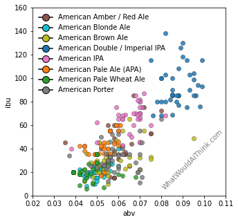

```python
plot1 = cPlot2D(
    X_min_max=(x_min, x_max),
    Y_min_max=(y_min, y_max),
    legend=legend,
    cDic=cDic,
    mMap=mMap,
)
plot1.plotInputData(dicData=df_new, dicStyles=dictStylesStylesInt)
plot1.save(os.path.join("images", "PlotBeersStyles.svg"))
```

# 3. Linear regression of craft beer

**Split the data into train and test data**

```python
from sklearn.linear_model import LinearRegression
from sklearn.model_selection import train_test_split
from sklearn.pipeline import Pipeline
from sklearn.preprocessing import StandardScaler
from sklearn.metrics import r2_score

X_train, X_test, y_train, y_test = train_test_split(
    df_new[["abv"]], df_new[["ibu"]], random_state=0, test_size=0.3
)
```

**Create a model for linear regression and train it**

```python
pseudorandom()
model = LinearRegression()

clf = Pipeline(
    steps=[
        ("standardscaler", StandardScaler()),
        ("linearregression", LinearRegression()),
    ]
)
clf.fit(X_train, y_train)
print(f"Train score: {clf.score(X_train, y_train):.2f}")
print(f"Test score: {clf.score(X_test, y_test):.2f}")
```

```
Train score: 0.62
Test score: 0.63
```

**Plot the data and the prediction from the linear model**

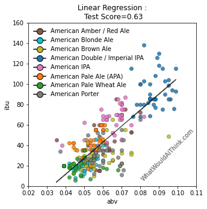

```python
# calc the r2Score for Train+TestData
ibu_predicted = clf.predict(df_new[["abv"]])
r2ScoreForTrainTestData = r2_score(df_new[["ibu"]], ibu_predicted)

# plot input
plot2 = cPlot2D(
    X_min_max=(x_min, x_max),
    Y_min_max=(y_min, y_max),
    legend=legend,
    cDic=cDic,
    mMap=mMap,
)
plot2.plotInputData(dicData=df_new, dicStyles=dictStylesStylesInt)

# plot prediction
plot2.ax.plot(df_new["abv"], ibu_predicted, c="black", alpha=0.7, label="prediction")
plot2.setTitle(f"Linear Regression :\n Test Score={r2ScoreForTrainTestData:.2f}")
plot2.save(os.path.join("images", "RegressionIbuAbv.svg"))
```

**Predict ibu with the linear model**

```python
display(
    clf.predict(
        pd.DataFrame([0.04, 0.05, 0.06, 0.07, 0.08, 0.09, 0.10], columns=["abv"])
    )
)
```

```
array([[ 11.68969489],
       [ 27.38458198],
       [ 43.07946907],
       [ 58.77435617],
       [ 74.46924326],
       [ 90.16413036],
       [105.85901745]])
```

# 4. Classification of craft beer

**Next we want to separate the different styles by classification with GridSearchCV**

```
##############################################
Classifier: Nearest_Neighbors
##############################################
Added: 'Nearest_Neighbors__n_jobs : [-1]' to tuning_parameters
Best Estimator:
Pipeline(steps=[('standardScaler', StandardScaler()),
                ('Nearest_Neighbors',
                 KNeighborsClassifier(algorithm='ball_tree', n_jobs=-1,
                                      n_neighbors=50))])

Best parameters set found:
```

```
{'Nearest_Neighbors__algorithm': 'ball_tree',
 'Nearest_Neighbors__n_jobs': -1,
 'Nearest_Neighbors__n_neighbors': 50,
 'Nearest_Neighbors__weights': 'uniform'}
```

```
Mean cross-validated score for the classifiers 'Nearest_Neighbors' : 0.54
Scorer used: make_scorer(accuracy_score)
Test score for the classifier 'Nearest_Neighbors' : 0.54
Not separable classes: []


##############################################
Classifier: Decision Tree
##############################################
Best Estimator:
Pipeline(steps=[('standardScaler', StandardScaler()),
                ('Decision Tree',
                 DecisionTreeClassifier(max_depth=3, min_samples_split=30))])

Best parameters set found:
```

```
{'Decision Tree__max_depth': 3, 'Decision Tree__min_samples_split': 30}
```

```
Mean cross-validated score for the classifiers 'Decision Tree' : 0.40
Scorer used: make_scorer(accuracy_score)
Test score for the classifier 'Decision Tree' : 0.44
Not separable classes: [ 4 18 20]


##############################################
Classifier: LogisticRegression
##############################################
Added: 'LogisticRegression__n_jobs : [-1]' to tuning_parameters
Added: 'LogisticRegression__max_iter : [100, 500, 1000]' to tuning_parameters
Best Estimator:
Pipeline(steps=[('standardScaler', StandardScaler()),
                ('LogisticRegression', LogisticRegression(n_jobs=-1))])

Best parameters set found:
```

```
{'LogisticRegression__max_iter': 100,
 'LogisticRegression__n_jobs': -1,
 'LogisticRegression__penalty': 'l2'}
```

```
Mean cross-validated score for the classifiers 'LogisticRegression' : 0.53
Scorer used: make_scorer(accuracy_score)
Test score for the classifier 'LogisticRegression' : 0.53
Not separable classes: []


##############################################
Classifier: GaussianProcess
##############################################
Added: 'GaussianProcess__n_jobs : [-1]' to tuning_parameters
Best Estimator:
Pipeline(steps=[('standardScaler', StandardScaler()),
                ('GaussianProcess',
                 GaussianProcessClassifier(max_iter_predict=10, n_jobs=-1))])

Best parameters set found:
```

```
{'GaussianProcess__max_iter_predict': 10, 'GaussianProcess__n_jobs': -1}
```

```
Mean cross-validated score for the classifiers 'GaussianProcess' : 0.53
Scorer used: make_scorer(accuracy_score)
Test score for the classifier 'GaussianProcess' : 0.55
Not separable classes: []


##############################################
Classifier: SVC
##############################################
Added: 'SVC__max_iter : [100, 500, 1000]' to tuning_parameters
Best Estimator:
Pipeline(steps=[('minmaxScaler', MinMaxScaler()),
                ('SVC', SVC(C=10, gamma=1, max_iter=100))])

Best parameters set found:
```

```
{'SVC__C': 10, 'SVC__gamma': 1, 'SVC__kernel': 'rbf', 'SVC__max_iter': 100}
```

```
Mean cross-validated score for the classifiers 'SVC' : 0.54
Scorer used: make_scorer(accuracy_score)
Test score for the classifier 'SVC' : 0.54
Not separable classes: []


##############################################
Classifier: SGD
##############################################
Added: 'SGD__n_jobs : [-1]' to tuning_parameters
Added: 'SGD__max_iter : [100, 500, 1000]' to tuning_parameters
Best Estimator:
Pipeline(steps=[('minmaxScaler', MinMaxScaler()),
                ('SGD',
                 SGDClassifier(alpha=0.001, loss='log', max_iter=500, n_jobs=-1,
                               penalty='l1'))])

Best parameters set found:
```

```
{'SGD__alpha': 0.001,
 'SGD__loss': 'log',
 'SGD__max_iter': 500,
 'SGD__n_jobs': -1,
 'SGD__penalty': 'l1'}
```

```
Mean cross-validated score for the classifiers 'SGD' : 0.47
Scorer used: make_scorer(accuracy_score)
Test score for the classifier 'SGD' : 0.55
Not separable classes: [4 9]


##############################################
Classifier: GaussianNB
##############################################
Best Estimator:
Pipeline(steps=[('standardScaler', StandardScaler()),
                ('GaussianNB', GaussianNB())])

Best parameters set found:
```

```
{'GaussianNB__var_smoothing': 1e-09}
```

```
Mean cross-validated score for the classifiers 'GaussianNB' : 0.51
Scorer used: make_scorer(accuracy_score)
Test score for the classifier 'GaussianNB' : 0.53
Not separable classes: []


##############################################
Classifier: QDA
##############################################
Best Estimator:
Pipeline(steps=[('standardScaler', StandardScaler()),
                ('QDA', QuadraticDiscriminantAnalysis(store_covariance=True))])

Best parameters set found:
```

```
{'QDA__store_covariance': True}
```

```
Mean cross-validated score for the classifiers 'QDA' : 0.52
Scorer used: make_scorer(accuracy_score)
Test score for the classifier 'QDA' : 0.55
Not separable classes: []


##############################################
Classifier: LDA
##############################################
Best Estimator:
Pipeline(steps=[('standardScaler', StandardScaler()),
                ('LDA', LinearDiscriminantAnalysis(store_covariance=True))])

Best parameters set found:
```

```
{'LDA__solver': 'svd', 'LDA__store_covariance': True}
```

```
Mean cross-validated score for the classifiers 'LDA' : 0.52
Scorer used: make_scorer(accuracy_score)
Test score for the classifier 'LDA' : 0.52
Not separable classes: []


##############################################
Classifier: Neural Net
##############################################
Added: 'Neural Net__max_iter : [100, 500, 1000]' to tuning_parameters
Best Estimator:
Pipeline(steps=[('standardScaler', StandardScaler()),
                ('Neural Net',
                 MLPClassifier(alpha=0.01, hidden_layer_sizes=10,
                               max_iter=1000))])

Best parameters set found:
```

```
{'Neural Net__activation': 'relu',
 'Neural Net__alpha': 0.01,
 'Neural Net__hidden_layer_sizes': 10,
 'Neural Net__max_iter': 1000,
 'Neural Net__solver': 'adam'}
```

```
Mean cross-validated score for the classifiers 'Neural Net' : 0.55
Scorer used: make_scorer(accuracy_score)
Test score for the classifier 'Neural Net' : 0.56
Not separable classes: []


##############################################
Best Model is Neural Net with a testscore of 0.56

The model Parameters are:
```

```
{'memory': None,
 'steps': [('standardScaler', StandardScaler()),
  ('Neural Net',
   MLPClassifier(alpha=0.01, hidden_layer_sizes=10, max_iter=1000))],
 'verbose': False,
 'standardScaler': StandardScaler(),
 'Neural Net': MLPClassifier(alpha=0.01, hidden_layer_sizes=10, max_iter=1000),
 'standardScaler__copy': True,
 'standardScaler__with_mean': True,
 'standardScaler__with_std': True,
 'Neural Net__activation': 'relu',
 'Neural Net__alpha': 0.01,
 'Neural Net__batch_size': 'auto',
 'Neural Net__beta_1': 0.9,
 'Neural Net__beta_2': 0.999,
 'Neural Net__early_stopping': False,
 'Neural Net__epsilon': 1e-08,
 'Neural Net__hidden_layer_sizes': 10,
 'Neural Net__learning_rate': 'constant',
 'Neural Net__learning_rate_init': 0.001,
 'Neural Net__max_fun': 15000,
 'Neural Net__max_iter': 1000,
 'Neural Net__momentum': 0.9,
 'Neural Net__n_iter_no_change': 10,
 'Neural Net__nesterovs_momentum': True,
 'Neural Net__power_t': 0.5,
 'Neural Net__random_state': None,
 'Neural Net__shuffle': True,
 'Neural Net__solver': 'adam',
 'Neural Net__tol': 0.0001,
 'Neural Net__validation_fraction': 0.1,
 'Neural Net__verbose': False,
 'Neural Net__warm_start': False}
```

```
##############################################
```

[figure not shown]

[figure not shown]

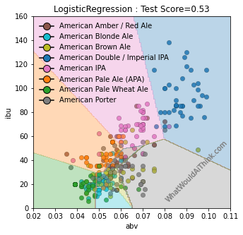

[figure not shown]

[figure not shown]

[figure not shown]

[figure not shown]

[figure not shown]

[figure not shown]

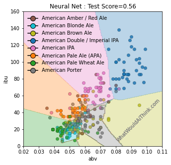

```python
from sklearn.neighbors import KNeighborsClassifier
from sklearn.tree import DecisionTreeClassifier
from sklearn.gaussian_process import GaussianProcessClassifier
from sklearn.svm import SVC
from sklearn.svm import LinearSVC
from sklearn.linear_model import SGDClassifier
from sklearn.gaussian_process.kernels import RBF
from sklearn.neural_network import MLPClassifier

from sklearn.ensemble import RandomForestClassifier, AdaBoostClassifier
from sklearn.naive_bayes import GaussianNB
from sklearn.discriminant_analysis import QuadraticDiscriminantAnalysis
from sklearn.discriminant_analysis import LinearDiscriminantAnalysis
from sklearn.linear_model import LogisticRegression

from sklearn.preprocessing import StandardScaler, MinMaxScaler
from sklearn.pipeline import make_pipeline
from sklearn.pipeline import Pipeline
from sklearn.model_selection import GridSearchCV

pseudorandom()

names = [
    "Nearest_Neighbors",
    "Decision Tree",
    "LogisticRegression",
    "GaussianProcess",
    "SVC",
    "SGD",
    "GaussianNB",
    "QDA",
    "LDA",
    "Neural Net",
]

# models to optimize
classifiers = [
    KNeighborsClassifier(),
    DecisionTreeClassifier(),
    LogisticRegression(),
    GaussianProcessClassifier(),
    SVC(),
    SGDClassifier(),
    GaussianNB(),
    QuadraticDiscriminantAnalysis(),
    LinearDiscriminantAnalysis(),
    MLPClassifier(),
]

# parameters to get optimized
tuning_parameters = {
    "Nearest_Neighbors": {
        "Nearest_Neighbors__n_neighbors": [5, 10, 20, 50],
        "Nearest_Neighbors__weights": ["uniform", "distance"],
        "Nearest_Neighbors__algorithm": ["ball_tree", "kd_tree", "brute"],
    },
    "Decision Tree": {
        "Decision Tree__max_depth": [1, 2, 3],
        "Decision Tree__min_samples_split": [5, 10, 20, 30],
    },
    "LogisticRegression": {
        "LogisticRegression__penalty": ["l1", "l2", "elasticnet", "none"]
    },
    "GaussianProcess": {"GaussianProcess__max_iter_predict": [10, 100, 1000]},
    "SVC": {
        "SVC__kernel": ["rbf", "poly", "sigmoid"],
        "SVC__gamma": [0.1, 1, 10],
        "SVC__C": [0.01, 0.1, 1, 10, 100],
    },
    "SGD": {
        "SGD__penalty": ["l1", "l2", "elasticnet"],
        "SGD__alpha": [0.0001, 0.001, 0.01, 0.1, 1, 10],
        "SGD__loss": ["hinge", "log", "modified_huber", "squared_hinge", "perceptron"],
    },
    "GaussianNB": {"GaussianNB__var_smoothing": [1e-9, 1e-6, 1e-3]},
    "QDA": {"QDA__store_covariance": [True, False]},
    "LDA": {
        "LDA__store_covariance": [True, False],
        "LDA__solver": ["svd", "lsqr", "eigen"],
    },
    "Neural Net": {
        "Neural Net__hidden_layer_sizes": [5, 10, 20, 30, 40, 50],
        "Neural Net__alpha": [0.0001, 0.001, 0.01, 0.1],
        "Neural Net__solver": ["lbfgs", "sgd", "adam"],
        "Neural Net__activation": ["identity", "logistic", "tanh", "relu"],
    },
}

# additional common tuning parameters will be add later
dicAddTuningParameters = {}
dicAddTuningParameters["n_jobs"] = [-1]
dicAddTuningParameters["max_iter"] = [100, 500, 1000]

stepSizeX = 0.0005
stepSizeY = 0.1
rowsPlot = 5
colsPlot = 2

# create a color list where the styles have the same color like plotted before
# add one level more as nedded to the level list to work correctly for the contour plot
levels = [0]
colors = []
for styleInt in np.sort(df_new["styleInt"].unique()):
    levels.append(styleInt)
    colors.append(cDic[styleInt])

# no splitting in test and train data needed, will be done by cross validation in GridSearch
X = df_new[["abv", "ibu"]]
y = df_new[["styleInt"]]

# iterate over classifiers and find the best model
bestScore = None
for index, (name, clf) in enumerate(zip(names, classifiers)):

    print(f"\n##############################################")
    print(f"Classifier: {name}")
    print(f"##############################################")

    # add tuning paramters to classifiers who support it
    for (key, value) in dicAddTuningParameters.items():
        if f"{key}" in clf.get_params().keys():
            tuning_parameters[name][f"{name}__{key}"] = value
            print(f"Added: '{name}__{key} : {value}' to tuning_parameters")

    # construct a pipeline with scaler and classifier
    if name in ["SVC", "SGD"]:
        # MinMaxScaler is recommended for SVC
        pipe = Pipeline(steps=[("minmaxScaler", MinMaxScaler()), (name, clf)])
    else:
        pipe = Pipeline(steps=[("standardScaler", StandardScaler()), (name, clf)])

    # search the best parameters
    # scoring=accuracy means 1.0 all lables were classified right
    gs = GridSearchCV(
        pipe, tuning_parameters[name], cv=5, scoring="accuracy", n_jobs=-1
    )
    gs.fit(X, y.to_numpy().ravel())

    # print(f"cv_results_: {gs.cv_results_}")
    print("Best Estimator: \n{}\n".format(gs.best_estimator_))
    print("Best parameters set found:")
    display(gs.best_params_)

    testScore = gs.best_score_
    print(f"Mean cross-validated score for the classifiers '{name}' : {testScore:.2f}")
    print(f"Scorer used: {gs.scorer_}")

    # Overwrite the testScore with the testscore of the best estimator
    clf = gs.best_estimator_
    clf.fit(X, y.to_numpy().ravel())
    testScore = clf.score(X, y)
    print(f"Test score for the classifier '{name}' : {testScore:.2f}")

    # store the best model and the testScore
    if index == 0:
        # set first model as best model
        bestScore = testScore
        bestModel = (name, testScore)
        dump(clf, "bestModel.joblib")
    else:
        if testScore >= bestScore:
            # model is better
            bestScore = testScore
            bestModel = (name, testScore)
            dump(clf, "bestModel.joblib")

    # predict the style
    xx, yy = np.meshgrid(
        np.arange(x_min, x_max + 0.01, stepSizeX), np.arange(y_min, y_max, stepSizeY)
    )
    Z = clf.predict(np.c_[xx.ravel(), yy.ravel()])

    # Check if all classes can be separated,
    # when UnknownClasses is empty means all classes were separated
    notSeparableClasses = clf.classes_
    for predictedClass in Z:
        if predictedClass in notSeparableClasses:
            indexFind = np.argwhere(notSeparableClasses == predictedClass)
            # delete each separated class
            notSeparableClasses = np.delete(notSeparableClasses, indexFind)

    # If notSeparableClasses is empty all classes could be separated
    print(f"Not separable classes: {notSeparableClasses}\n")

    # plot the prediction
    Z = Z.reshape(xx.shape)

    # plotting each plot separately
    if showSubPlotsSeparately:
        plot3 = cPlot2D(
            X_min_max=(x_min, x_max),
            Y_min_max=(y_min, y_max),
            legend=legend,
            cDic=cDic,
            mMap=mMap,
        )
        # plot the input
        plot3.plotInputData(dicData=df_new, dicStyles=dictStylesStylesInt)
        # plot the prediction
        plot3.ax.contourf(xx, yy, Z, levels=levels, colors=colors, alpha=0.3)
        plot3.setTitle(f"{names[index]} : Test Score={testScore:.2f}")
        plot3.save(
            os.path.join(
                "images", "classification", f"PlotBeersClassification_{name}.svg"
            )
        )

    # plot all models in subfigures
    else:
        if index == 0:
            plot4 = cPlot2D(
                X_min_max=(x_min, x_max),
                Y_min_max=(y_min, y_max),
                legend=legend,
                cDic=cDic,
                mMap=mMap,
                figsize=(8 * colsPlot, 8 * rowsPlot),
            )

        plot4.ax = plt.subplot(rowsPlot, colsPlot, index + 1)
        # plot the input
        plot4.plotInputData(dicData=df_new, dicStyles=dictStylesStylesInt)
        # plot the prediction
        plot4.ax.contourf(xx, yy, Z, levels=levels, colors=colors, alpha=0.3)
        plot4.setTitle(f"{names[index]} : {testScore:.2f}")

        if index == len(names) - 1:
            plot4.save(
                os.path.join(
                    "images", "classification", f"PlotBeersClassification_All.svg"
                )
            )

print(f"\n##############################################")
print(f"Best Model is {bestModel[0]} with a testscore of {bestModel[1]:.2f}\n")
print(f"The model Parameters are:\n")
clf = load("bestModel.joblib")
display(clf.get_params())
print(f"##############################################")
```

# 5. Clustering of craft beer

**Next we want to separate the different styles by clustering with GridSearchCV. Define a function for unsupervised and supervised clustering**

```python
from sklearn.cluster import DBSCAN
from sklearn.cluster import OPTICS
from sklearn.cluster import AgglomerativeClustering
from sklearn.cluster import MeanShift
from sklearn.cluster import KMeans
from sklearn.cluster import SpectralClustering
from sklearn.mixture import GaussianMixture
from sklearn.cluster import Birch
from sklearn import metrics
from sklearn import base
import pylab as pl
from mpl_toolkits.axes_grid1.inset_locator import inset_axes
from sklearn.metrics import silhouette_score as sc
from numpy import genfromtxt

pseudorandom()


def randScore(estimator: base.BaseEstimator, X: pd.DataFrame) -> metrics:
    """Compute the rand index. Ground truth is needed."""
    predictedLabels = estimator.fit_predict(X)
    # only way to pass the true labels
    trueLabels = genfromtxt("trueLabels.csv", delimiter=",")
    return metrics.rand_score(trueLabels, predictedLabels)


def silhouetteScore(estimator: base.BaseEstimator, X: pd.DataFrame) -> metrics:
    """Compute the silhouette coefficient. Ground truth is not needed."""
    # ground truth not known
    predictedLabels = estimator.fit_predict(X)
    return metrics.silhouette_score(X, predictedLabels, metric="euclidean")


def gridSearchCvClustering(groundTruth: bool):
    """Perform supervised or unsupervised clustering
    with GridSearchCV for the models
    DBSCAN, OPTICS, MeanShift, AgglomerativeClustering,
    KMeans, SpectralClustering, GaussianMixture.
    """

    names = [
        "DBSCAN",
        "OPTICS",
        "MeanShift",
        "AgglomerativeClustering",
        "KMeans",
        "SpectralClustering",
        "GaussianMixture",
    ]

    clusterModels = [
        DBSCAN(),
        OPTICS(),
        MeanShift(),
        AgglomerativeClustering(),
        KMeans(),
        SpectralClustering(),
        GaussianMixture(),
    ]

    # parameters to get optimized
    tuning_parameters = {}
    tuning_parameters = {
        "DBSCAN": {
            "metric": ["cityblock", "l1", "l2", "manhattan", "cosine", "precomputed"],
            "algorithm": ["auto", "ball_tree", "kd_tree", "brute"],
            "eps": [0.1, 0.3, 0.5, 0.7, 0.9, 1],
        },
        "OPTICS": {
            "metric": ["cityblock", "l1", "l2", "manhattan", "cosine", "precomputed"],
            "algorithm": ["auto", "ball_tree", "kd_tree", "brute"],
            "eps": [0.1, 0.3, 0.5, 0.7, 0.9, 1],
            "cluster_method": ["dbscan", "xi"],
        },
        "MeanShift": {},
        "AgglomerativeClustering": {
            "linkage": ["ward", "complete", "average", "single"],
            "affinity": ["euclidean", "l1", "l2", "manhattan", "cosine", "precomputed"],
        },
        "KMeans": {
            "init": ["k-means++", "random"],
            "algorithm": ["elkan", "auto", "full"],
        },
        "SpectralClustering": {
            "affinity": ["nearest_neighbors", "rbf"],
            "eigen_solver": ["arpack", "lobpcg", "amg"],
            "n_neighbors": [5, 10, 20, 30, 40],
        },
        "GaussianMixture": {
            "n_components": [2, 3, 4, 5, 6, 7, 8, 9, 10],
            "covariance_type": ["full", "tied", "diag", "spherical"],
            "init_params": ["kmeans", "k-means++", "random", "random_from_data"],
        },
    }

    # additional common tuning parameters will be add later
    dicAddTuningParameters = {}
    dicAddTuningParameters["n_init"] = [1, 2, 3]
    dicAddTuningParameters["n_clusters"] = [2, 5, 6, 8, 9]
    dicAddTuningParameters["min_samples"] = [10, 20, 30, 40, 60]
    dicAddTuningParameters["max_iter"] = [100, 300, 500, 700]

    stepSizeX = 0.0005
    stepSizeY = 0.1
    rowsPlot = 5
    colsPlot = 2

    # create a markermap
    mMap = ["v", "D", "s", "H", ">", "X", "P", "<", "^", "o", "+", "x", "*", "h", "d"]
    # create a new colormap for the predicted Clusters
    cMap = [
        "deepskyblue",
        "slategray",
        "deeppink",
        "palegreen",
        "peru",
        "darkviolet",
        "teal",
        "magenta",
        "blue",
        "red",
        "azure",
        "orange",
        "lime",
        "yellow",
        "darkred",
    ]

    # create a dictionarys for color and marker
    dicLabels = {}
    dicMarkers = {}

    # all noisy samples are labeled as -1 and will be colored black
    for label in np.arange(-1, len(mMap), 1):
        if label == -1:
            dicLabels[-1] = "black"
            dicMarkers[-1] = "."
        else:
            dicLabels[label] = cMap[label]
            dicMarkers[label] = mMap[label]

    print(f"dicLabels: {dicLabels}")
    print(f"dicLabels: {dicMarkers}")

    X = df_new[["abv", "ibu"]].to_numpy()
    y = df_new[["styleInt"]].to_numpy()

    # save the true labels to read it in the scorer callable
    np.savetxt("trueLabels.csv", y[:, 0], delimiter=",")

    bestModel = ("name", None)
    bestScore = None
    index = 0

    # iterate over clustering algorithms
    for index, (name, _clf) in enumerate(zip(names, clusterModels)):
        # reset
        uniqueLabels = None
        clf = _clf

        print(f"\n##############################################")
        print(f"ClusterModel: {name}")
        print(f"##############################################")

        # add tuning paramters to classifiers who support it
        for (key, value) in dicAddTuningParameters.items():
            if f"{key}" in clf.get_params().keys():
                tuning_parameters[name][f"{key}"] = value
                print(f"Added: '{key} : {value}' to tuning_parameters")

        # defining the test score
        if groundTruth == True:
            scoring = randScore
        else:
            scoring = silhouetteScore

        # search the best parameters
        gs = GridSearchCV(
            estimator=clf,
            param_grid=tuning_parameters[name],
            scoring=scoring,
            cv=[(slice(None), slice(None))],
            n_jobs=-1,
        )
        gs.fit(X)

        clf = gs.best_estimator_
        predictedLabels = clf.fit_predict(X)
        print(f"ClusterModel: {name}")
        print(f"scoring: {scoring.__name__}")
        print(f"Best parameters set found: {gs.best_params_}")
        testScore = gs.best_score_
        print(f"Test score for clusterModels {name}: {testScore:.2f}")

        # decrement the number of uniqueLabels by 1 if noisy label are included
        if -1 in predictedLabels:
            uniqueLabels = len(np.unique(predictedLabels)) - 1
        else:
            uniqueLabels = len(np.unique(predictedLabels))

        print(f"Found {uniqueLabels} unique labels")
        print(f"The predicted labels are: {predictedLabels}")

        # store the best model and the testScore
        if index == 0:
            # set first model as best model
            bestScore = testScore
            bestModel = (name, testScore)
            dump(clf, "bestModel.joblib")
        else:
            if testScore > bestScore:
                # model is better
                bestScore = testScore
                bestModel = (name, testScore)
                dump(clf, "bestModel.joblib")

        # plotting each plot separately
        if showSubPlotsSeparately:
            plot6 = cPlot2D(
                X_min_max=(x_min, x_max),
                Y_min_max=(y_min, y_max),
                legend=[],
                cDic=cDic,
                mMap=mMap,
            )

            # Plot the original data in the figure, by creating an inset in the top left corner
            axins = inset_axes(
                plot6.ax,
                width="80%",
                height="80%",
                bbox_to_anchor=(0.08, 0.5, 0.5, 0.5),
                bbox_transform=plot6.ax.transAxes,
                loc=2,
            )
            axins.set_xlim(x_min, x_max)
            axins.set_ylim(y_min, y_max)
            axins.set(xticks=[0.03, 0.06, 0.09], yticks=[0, 50, 100, 150])
            # axins.axes.xaxis.set_visible(False)
            # axins.axes.yaxis.set_visible(False)

            # plot the input
            for i, (key, value) in enumerate(dictStylesStylesInt.items()):
                df_filterByStyle = df_new.loc[(df_new["styleInt"] == value)]
                axins.scatter(
                    df_filterByStyle["abv"],
                    df_filterByStyle["ibu"],
                    c=cDic[value],
                    marker="o",
                    alpha=0.85,
                    s=10,
                )

            # plot the prediction
            for j, value in enumerate(X):
                plot6.ax.scatter(
                    X[j, 0],
                    X[j, 1],
                    color=dicLabels[predictedLabels[j]],
                    marker=dicMarkers[predictedLabels[j]],
                    alpha=0.85,
                    s=20,
                )

            plot6.setTitle(
                f"{names[index]} :\n Test Score={testScore:.2f} ; Clusters={uniqueLabels}"
            )
            plot6.save(
                os.path.join(
                    "images",
                    "clustering",
                    f"PlotBeersClustering_{name}_{scoring.__name__}.svg",
                )
            )

        # plot all models in subfigures in one figure
        else:
            if index == 0:
                plot7 = cPlot2D(
                    X_min_max=(x_min, x_max),
                    Y_min_max=(y_min, y_max),
                    legend=legend,
                    cDic=cDic,
                    mMap=mMap,
                    figsize=(8 * colsPlot, 8 * rowsPlot),
                )

            plot7.ax = plt.subplot(rowsPlot, colsPlot, index + 1)

            # Plot the original data in the figure, by creating an inset in the top left corner
            axins = inset_axes(
                plot7.ax,
                width="80%",
                height="80%",
                bbox_to_anchor=(0.08, 0.5, 0.5, 0.5),
                bbox_transform=plot7.ax.transAxes,
                loc=2,
            )
            axins.set_xlim(x_min, x_max)
            axins.set_ylim(y_min, y_max)
            axins.set(xticks=[0.03, 0.06, 0.09], yticks=[0, 50, 100, 150])

            # plot the input
            for i, (key, value) in enumerate(dictStylesStylesInt.items()):
                df_filterByStyle = df_new.loc[(df_new["styleInt"] == value)]
                axins.scatter(
                    df_filterByStyle["abv"],
                    df_filterByStyle["ibu"],
                    c=cDic[value],
                    marker="o",
                )

            # plot the prediction
            for j, value in enumerate(X):
                plot7.ax.scatter(
                    X[j, 0],
                    X[j, 1],
                    color=dicLabels[predictedLabels[j]],
                    marker=dicMarkers[predictedLabels[j]],
                    alpha=0.85,
                    s=20,
                )
            plot7.setTitle(f"{names[index]} : Test Score={testScore:.2f}")

            if index == len(name) - 1:
                plot7.save(
                    os.path.join(
                        "images",
                        "clustering",
                        f"PlotBeersClustering_All_{scoring.__name__}.svg",
                    )
                )

    print(f"\n##############################################")
    print(f"Best Model is {bestModel[0]} with a testscore of {bestModel[1]:.2f}\n")
    print(f"The model Parameters are:\n")
    clf = load("bestModel.joblib")
    display(clf.get_params())
    print(f"##############################################")
```

## 5.1 Unsupervised clustering of craft beer

```
dicLabels: {-1: 'black', 0: 'deepskyblue', 1: 'slategray', 2: 'deeppink', 3: 'palegreen', 4: 'peru', 5: 'darkviolet', 6: 'teal', 7: 'magenta', 8: 'blue', 9: 'red', 10: 'azure', 11: 'orange', 12: 'lime', 13: 'yellow', 14: 'darkred'}
dicLabels: {-1: '.', 0: 'v', 1: 'D', 2: 's', 3: 'H', 4: '>', 5: 'X', 6: 'P', 7: '<', 8: '^', 9: 'o', 10: '+', 11: 'x', 12: '*', 13: 'h', 14: 'd'}

##############################################
ClusterModel: DBSCAN
##############################################
Added: 'min_samples : [10, 20, 30, 40, 60]' to tuning_parameters
ClusterModel: DBSCAN
scoring: silhouetteScore
Best parameters set found: {'algorithm': 'auto', 'eps': 1, 'metric': 'cityblock', 'min_samples': 20}
Test score for clusterModels DBSCAN: -0.09
Found 1 unique labels
The predicted labels are: [-1 -1 -1 -1 -1 -1 -1 -1 -1 -1 -1 -1 -1 -1 -1 -1 -1  0 -1 -1 -1 -1 -1 -1
 -1 -1 -1 -1 -1 -1 -1 -1 -1 -1  0 -1 -1 -1 -1 -1 -1 -1 -1 -1 -1 -1 -1 -1
 -1 -1 -1 -1 -1 -1 -1 -1 -1 -1 -1 -1 -1 -1 -1 -1 -1 -1 -1 -1 -1 -1 -1 -1
 -1 -1  0 -1 -1 -1 -1 -1 -1 -1 -1 -1 -1 -1 -1 -1 -1 -1 -1 -1 -1 -1 -1 -1
 -1 -1  0 -1 -1 -1 -1 -1 -1 -1 -1 -1 -1 -1 -1 -1 -1 -1 -1  0 -1 -1 -1 -1
 -1 -1 -1 -1 -1 -1 -1 -1 -1 -1 -1 -1 -1 -1 -1 -1 -1 -1 -1 -1 -1 -1 -1 -1
 -1 -1 -1 -1 -1 -1 -1 -1 -1 -1 -1 -1 -1 -1 -1 -1 -1 -1 -1 -1 -1 -1 -1 -1
 -1 -1 -1 -1 -1 -1 -1 -1 -1 -1 -1 -1 -1  0 -1  0 -1 -1  0 -1 -1 -1 -1  0
 -1 -1 -1 -1 -1 -1  0 -1 -1 -1 -1 -1 -1 -1 -1 -1 -1 -1 -1 -1 -1 -1 -1 -1
 -1 -1  0 -1 -1  0  0  0  0  0  0  0  0  0  0  0  0  0  0  0 -1 -1  0 -1
 -1 -1 -1 -1 -1 -1 -1 -1 -1 -1 -1  0 -1 -1 -1 -1 -1 -1 -1 -1 -1 -1 -1 -1
 -1 -1 -1 -1 -1 -1 -1 -1 -1 -1 -1 -1 -1 -1 -1 -1 -1 -1 -1  0  0 -1 -1 -1
 -1 -1 -1 -1 -1 -1 -1 -1 -1 -1  0 -1 -1  0 -1 -1]

##############################################
ClusterModel: OPTICS
##############################################
Added: 'min_samples : [10, 20, 30, 40, 60]' to tuning_parameters
ClusterModel: OPTICS
scoring: silhouetteScore
Best parameters set found: {'algorithm': 'auto', 'cluster_method': 'xi', 'eps': 0.1, 'metric': 'cityblock', 'min_samples': 40}
Test score for clusterModels OPTICS: 0.36
Found 1 unique labels
The predicted labels are: [-1 -1 -1 -1 -1 -1 -1 -1 -1  0  0 -1 -1 -1 -1 -1 -1  0 -1 -1 -1 -1 -1 -1
 -1 -1 -1 -1  0  0 -1  0  0 -1  0  0 -1  0 -1  0 -1  0 -1 -1 -1 -1 -1 -1
 -1 -1 -1  0  0 -1 -1 -1 -1 -1 -1 -1 -1 -1 -1 -1 -1 -1  0 -1 -1 -1 -1  0
 -1 -1  0 -1 -1 -1 -1 -1 -1  0  0 -1 -1 -1  0 -1 -1 -1 -1 -1 -1  0 -1 -1
 -1  0  0 -1 -1 -1 -1  0 -1  0 -1 -1 -1 -1 -1 -1 -1 -1  0  0  0  0  0 -1
```

[output cut: 97 more lines]

```
Found 2 unique labels
The predicted labels are: [1 0 1 1 1 1 0 1 1 0 0 0 1 1 1 0 1 0 1 0 1 1 0 0 1 0 0 1 0 0 1 0 0 1 0 0 0
 0 0 0 1 0 1 1 0 0 1 0 0 0 1 0 0 0 0 1 0 0 1 1 0 0 1 1 1 0 0 1 1 0 1 0 1 1
 0 1 1 1 0 1 0 0 0 0 1 0 0 1 0 0 1 0 0 0 0 1 0 0 0 0 1 1 1 0 0 0 0 0 0 0 0
 0 0 0 0 0 0 0 0 0 0 1 0 1 0 0 0 0 0 0 0 0 0 0 0 0 0 0 0 1 0 0 0 1 1 0 0 1
 0 1 1 0 1 0 0 0 0 0 0 0 0 0 0 0 1 0 0 1 0 0 1 0 0 0 0 1 1 1 0 0 1 0 0 0 0
 0 0 0 0 0 0 0 0 0 1 0 0 0 0 0 0 0 0 0 0 0 0 0 0 0 1 0 0 0 0 0 1 0 0 0 0 0
 0 0 0 0 0 0 0 0 0 0 0 0 0 0 0 0 0 1 1 0 0 0 0 0 1 1 0 1 0 0 0 0 0 0 0 0 0
 1 1 1 1 0 0 1 1 1 1 0 0 0 1 1 0 0 0 0 0 1 0 0 0 0 0 0 1 0 0 0 0 0 0 0 0 0
 0 0 0 0 0 0 0 0]

##############################################
Best Model is AgglomerativeClustering with a testscore of 0.68

The model Parameters are:
```

```
{'affinity': 'euclidean',
 'compute_distances': False,
 'compute_full_tree': 'auto',
 'connectivity': None,
 'distance_threshold': None,
 'linkage': 'complete',
 'memory': None,
 'n_clusters': 2}
```

```
##############################################
```

[figure not shown]

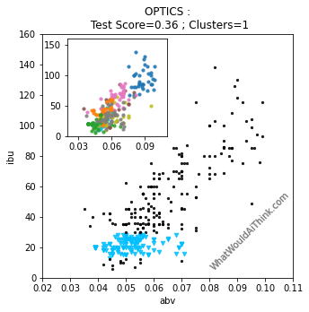

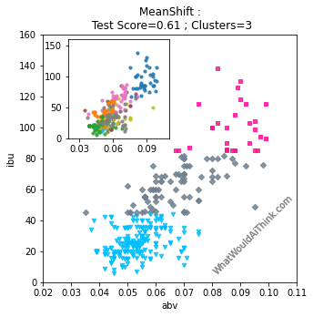

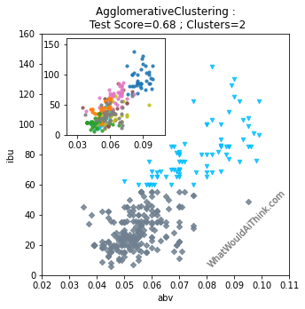

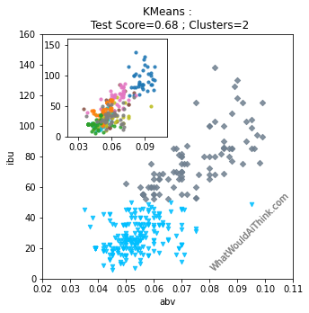

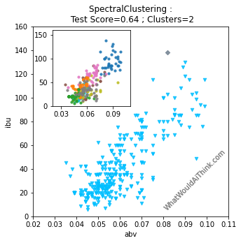

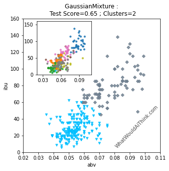

```python
gridSearchCvClustering(groundTruth=False)
```

## 5.2 Supervised clustering of craft beer

```
dicLabels: {-1: 'black', 0: 'deepskyblue', 1: 'slategray', 2: 'deeppink', 3: 'palegreen', 4: 'peru', 5: 'darkviolet', 6: 'teal', 7: 'magenta', 8: 'blue', 9: 'red', 10: 'azure', 11: 'orange', 12: 'lime', 13: 'yellow', 14: 'darkred'}
dicLabels: {-1: '.', 0: 'v', 1: 'D', 2: 's', 3: 'H', 4: '>', 5: 'X', 6: 'P', 7: '<', 8: '^', 9: 'o', 10: '+', 11: 'x', 12: '*', 13: 'h', 14: 'd'}

##############################################
ClusterModel: DBSCAN
##############################################
Added: 'min_samples : [10, 20, 30, 40, 60]' to tuning_parameters
ClusterModel: DBSCAN
scoring: randScore
Best parameters set found: {'algorithm': 'auto', 'eps': 1, 'metric': 'cityblock', 'min_samples': 10}
Test score for clusterModels DBSCAN: 0.57
Found 7 unique labels
The predicted labels are: [-1 -1 -1 -1 -1 -1 -1 -1 -1 -1 -1  3 -1 -1 -1 -1 -1  0 -1 -1 -1 -1  1 -1
 -1 -1 -1 -1 -1 -1 -1 -1 -1 -1  0 -1  2 -1  3  4 -1 -1 -1 -1  1  1 -1 -1
 -1 -1 -1 -1 -1 -1 -1 -1 -1 -1 -1 -1  3  3 -1 -1 -1  1 -1 -1 -1  3  6 -1
 -1 -1  0 -1  6 -1  2 -1  1 -1 -1  1 -1  1 -1 -1 -1 -1 -1 -1  3 -1  3  3
 -1 -1  0  1 -1 -1 -1 -1  3 -1 -1  1  1  1 -1 -1 -1 -1 -1  0 -1 -1 -1 -1
 -1 -1 -1 -1 -1 -1 -1  4  1  1  4  2 -1  2  2  2  2  2 -1 -1 -1  1 -1 -1
 -1 -1 -1 -1 -1 -1 -1  4 -1 -1 -1  2  4  4 -1 -1  4  4 -1 -1 -1 -1 -1 -1
 -1 -1  6 -1 -1 -1 -1 -1 -1 -1 -1  5 -1  0 -1  0 -1 -1  0 -1 -1 -1 -1  0
 -1 -1 -1  1 -1 -1  0 -1  5 -1  5 -1 -1 -1  5  5  5  4 -1  1 -1  4 -1 -1
 -1  5  0 -1 -1  0  0  0  0  0  0  0  0  0  0  0  0  0  0  0 -1 -1  0 -1
  6 -1 -1 -1 -1 -1  6 -1  4 -1 -1  0 -1 -1  5 -1 -1 -1 -1 -1 -1 -1 -1 -1
  5  6  6  6  6  4 -1  4 -1  6 -1  4 -1  4 -1  2  4 -1  1  0  0 -1  2 -1
 -1 -1  3  3  1 -1  5  1 -1 -1  0 -1  1  0  5 -1]

##############################################
ClusterModel: OPTICS
##############################################
Added: 'min_samples : [10, 20, 30, 40, 60]' to tuning_parameters
ClusterModel: OPTICS
scoring: randScore
Best parameters set found: {'algorithm': 'auto', 'cluster_method': 'xi', 'eps': 0.1, 'metric': 'cosine', 'min_samples': 10}
Test score for clusterModels OPTICS: 0.75
Found 12 unique labels
The predicted labels are: [ 0  0  1  1  1  0  0 -1 -1 10 -1  2 -1  3  0  4  4 10 -1  1  2 -1  5  5
  3 -1  5 -1 -1 -1 -1 -1  7 -1 10 -1  2 11 -1  7 -1 -1  0 -1 -1  6 -1 -1
 -1  3 -1 11  8  5  5 -1  2 -1 -1  1  3 -1  1  2 -1 -1 -1  1  3 -1  3  8
  3 -1 -1 -1  3  4  2 -1  5  7  7  5 -1  5  7 -1 -1  4 -1 -1  4 -1 -1 -1
  5 -1  9 -1  1  1  1 -1 -1 -1 -1  5 -1  5  2  2 -1 -1 -1 -1  7 11 -1  5
```

[output cut: 97 more lines]

```
Found 8 unique labels
The predicted labels are: [4 6 8 8 8 0 6 8 8 2 5 6 8 8 0 3 0 5 8 6 8 4 1 6 0 4 4 8 5 5 8 5 5 8 2 6 4
 6 3 5 4 5 8 0 6 6 0 5 1 4 8 5 5 4 4 8 6 6 8 8 6 3 4 8 8 6 5 8 0 4 8 5 8 8
 5 0 8 8 4 8 1 5 5 1 8 1 5 8 4 4 0 3 4 5 4 3 3 5 2 1 0 4 4 1 4 6 5 1 4 1 4
 4 6 1 5 5 5 5 5 4 4 0 4 0 6 4 4 5 6 6 5 4 5 4 4 4 4 4 5 0 5 6 5 8 0 6 4 0
 5 0 8 5 8 1 5 4 5 5 5 4 5 5 6 5 0 6 6 0 5 4 0 5 4 2 5 8 8 0 5 5 8 2 5 2 5
 4 5 5 6 5 5 5 6 6 0 4 2 2 2 2 5 6 5 6 1 6 5 6 6 5 0 6 1 6 5 5 0 2 5 4 5 5
 5 5 2 2 2 2 2 2 2 2 2 2 2 2 4 5 2 0 0 5 5 6 2 6 0 0 6 0 5 5 6 6 2 5 5 5 5
 0 0 0 0 5 6 0 0 0 0 6 6 6 8 0 5 5 5 5 5 8 5 6 4 6 6 5 8 4 5 5 4 4 6 1 2 6
 6 4 5 4 6 5 5 6]

##############################################
Best Model is GaussianMixture with a testscore of 0.84

The model Parameters are:
```

```
{'covariance_type': 'diag',
 'init_params': 'random',
 'max_iter': 700,
 'means_init': None,
 'n_components': 9,
 'n_init': 2,
 'precisions_init': None,
 'random_state': None,
 'reg_covar': 1e-06,
 'tol': 0.001,
 'verbose': 0,
 'verbose_interval': 10,
 'warm_start': False,
 'weights_init': None}
```

```
##############################################
```

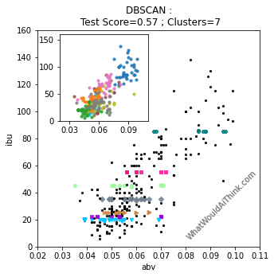

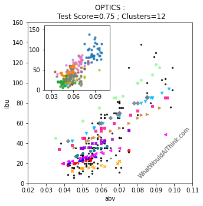

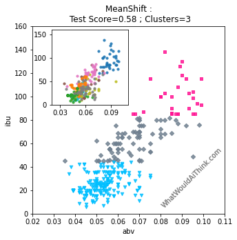

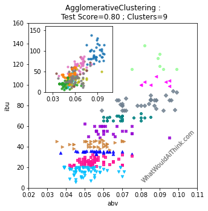

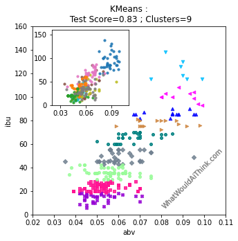

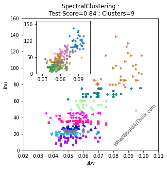

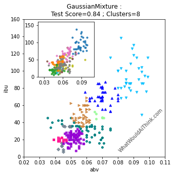

```python
gridSearchCvClustering(groundTruth=True)
```

**The end**